# Multiple Testing

Pietro Franceschi | pietro.franceschi@fmach.it

## Where we left off

In a single test, we accept a false positive rate of $\alpha = 0.05$.

This means: if H0 is true, we wrongly reject it **5% of the time**.

⚠️ **The metabolomics reality:**  
We do not test *one* hypothesis. We simultaneously test **hundreds or thousands** of variables.

## A concrete example

Imagine a metabolomics experiment:

- **2 groups** of samples (treated vs control)
- **1000 metabolites** measured for each sample
- A **t-test** for every metabolite → 1000 p-values
- We flag anything with $p < 0.05$ as “significant”

How many false positives should we expect?

## Expected false positives

If none of the 1000 metabolites truly differ between groups:

$$\text{Expected false positives} = 1000
\times 0.05 = \mathbf{50}$$

We would report **50 “significant” metabolites** — all of them artefacts.

Performing many tests inflates the probability of finding something by chance alone.

# Visualising the problem

## p-values under H₀

When there is **no real effect**, p-values follow a uniform distribution between 0 and 1.

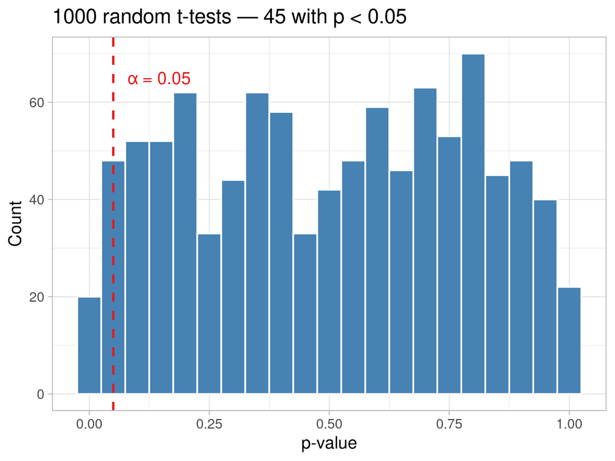

## When there ARE real effects

If some variables truly differ between groups, the histogram is no longer flat: a spike appears near zero on top of the uniform background.

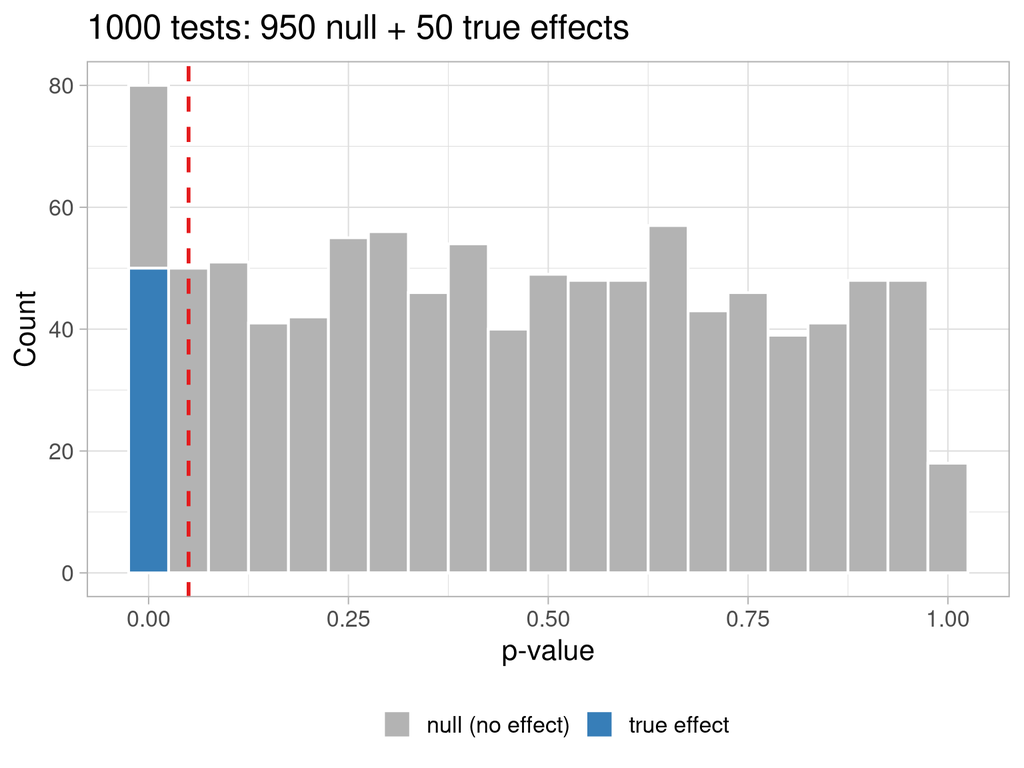

## Reading the mixed histogram

- The **flat part** across the full range → null features (false positives hiding here)
- The **spike near zero** → true positives piling up at small p-values
- The height of the spike above the flat baseline is proportional to the number of real effects
- A spike + flat pattern is the signature of a real experiment with **some** true signal

**Practical tip:** always plot the p-value histogram before applying any correction — it tells you immediately whether your data contains any signal at all.

# Correction methods

## Two families of solutions

1. **Control FWER** — ensure the probability of *any* false positive stays below $\alpha$
   - Bonferroni, Holm
   - Very conservative; appropriate when every false positive is dangerous
2. **Control FDR** — ensure the *proportion* of false positives among findings stays below $\alpha$
   - Benjamini-Hochberg
   - Less conservative; appropriate for discovery science

## Family-wise error rate (FWER)

The probability of making **at least one** false positive across $m$ independent tests:

$$\text{FWER} = 1 - (1 -
\alpha)^{m}$$

| Tests ($m$) | FWER at $\alpha = 0.05$ |
| --- | --- |
| 1 | 0.05 |
| 10 | 0.40 |
| 50 | 0.92 |
| 100 | 0.994 |
| 1000 | ≈ 1 |

## Bonferroni correction

The simplest FWER control: divide the threshold by the number of tests.

$$\alpha_{\text{Bonf}} =
\frac{\alpha}{m}$$

For $m = 1000$ and $\alpha = 0.05$:

$$\alpha_{\text{Bonf}} = \frac{0.05}{1000}
= 0.00005$$

⚠️ **Very conservative.** A true positive must produce an extremely small p-value to survive. In metabolomics with correlated variables this is often too strict.

## False Discovery Rate (FDR)

Introduced by **Benjamini & Hochberg (1995)** — one of the most cited papers in statistics.

Instead of controlling the probability of *any* false positive, control the **expected proportion** of false positives among all discoveries:

$$\text{FDR} = E\left[\frac{\text{false
positives}}{\text{total discoveries}}\right]$$

The resulting corrected p-values are called q-values.

A q-value of 0.05 means: among all features with $q \leq 0.05$, we expect at most **5% to be false positives**.

# Summary

## Take-home messages

⚠️ **Never report uncorrected p-values** when testing many hypotheses

- The **number of tests** matters as much as the threshold
- **Bonferroni**: strict FWER control (clinical, confirmatory)
- **Benjamini-Hochberg**: discovery (metabolomics, exploratory)
- Inspect the **p-value histogram**: spike near 0, flat elsewhere
- Significance is not enough: pair it with an effect size (Cohen’s d)

Hundreds of features without correction: a results list dominated by noise. With FDR control, discoveries are principled.